# AJindex

Ana De Las Alas

5/21/2019

## Introduction

Our team is focusing on data about endangered and threatened species in the U.S. The dataset includes data about specific endangered species and their respective attributes, such as the region of the U.S. they are found in, their species group, and their critical habitat type. With this domain, we can investigate questions like which species group contains the most endangered species, which region is likely to contain certain species groups, and what are the patterns in how many acres are allotted to create critical habitats for these species. The following report will highlight summary information about the dataset as well as three visualizations that convey key points about the data.

## Summary Information

Within the dataset, there are 657 total endangered species and 187 total threatened species documented. The percentage of species that are endangered is 77.84%. Our dataset shows which species group each species belongs to. Based on our calculations, we found that there were 40 mammals documented in the dataset, which means that 4.74% of the species from the data are mammals. The organization separated the U.S. into 9 regions so that readers can better understand where each species in the dataset comes from. This information helps our team recognize that there are more endangered species than threatened species, that mammals make up a small percentage of endangered species, and that the location of the species is dependent on region rather than state or city.

## Chart One: Boxplot

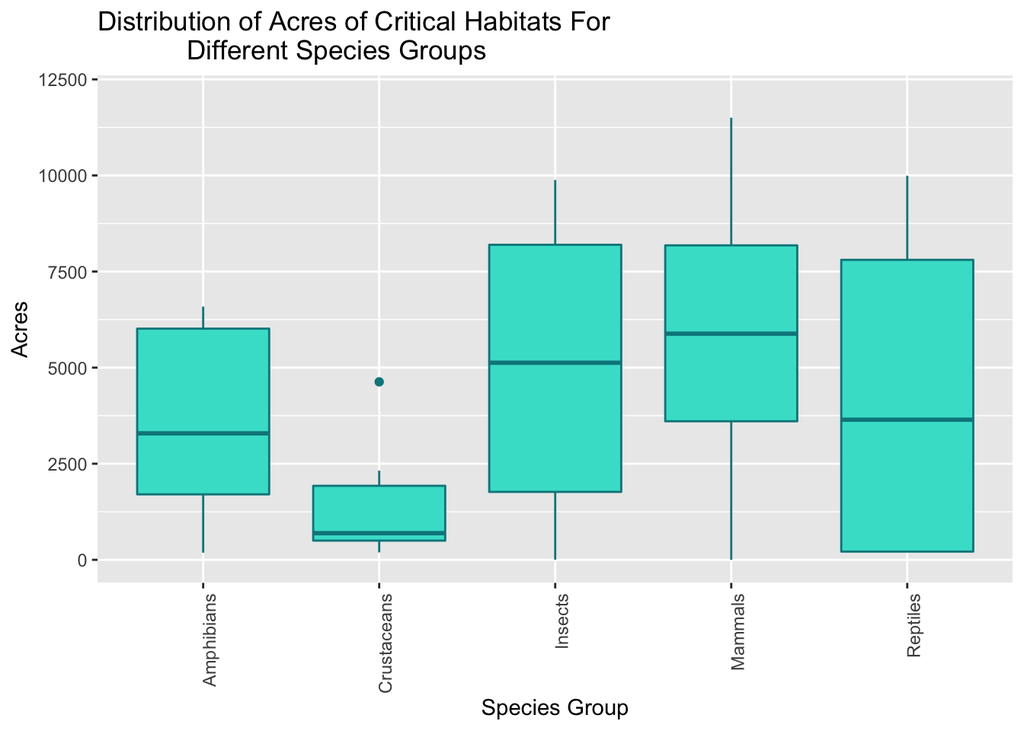